# Writing functions and computing indices

From a working script to spatial segregation functions

Authors

Javier San Millán Tejedor

Daniele Cannatella

Published

November 10, 2026

## Introduction

In this code-along we move from using existing segregation packages to **writing the functions ourselves**. We start from a working script that computes a spatial Information Theory Index (SITI) and a Spatial Rank-Ordered Information Theory Index (SROITI) for one district of Barcelona. We then use it as the basis for a group exercise in reading, fixing and generalising R functions.

Aims of this session:

1. read someone else’s analysis script and work out what each block does
2. turn repeated calculations into functions with clear inputs and outputs
3. find and fix the rough edges together, including a package compatibility patch that works but that none of us are fully happy with yet

The workflow, in one line: **download income and population by census tract → choose an area → turn income bands into “share of people below threshold X” → measure how unevenly those people are spread in space (SITI), at several spatial scales → summarise all thresholds into one number per scale (SROITI).**

## Preparation

```r
# Install packages once (uncomment on first run)
# install.packages(c("pak", "ineAtlas", "sf", "tidyverse"))
# pak::pak("syunhong/seg")
# pak::pak(c("pablogguz/ineAtlas", "syunhong/seg")) # seg was removed from CRAN: install it from GitHub

library(ineAtlas)   # Spanish income atlas (INE) by census tract
library(tidyverse)  # data wrangling + ggplot2
library(sf)         # spatial data
library(seg)        # spatial segregation indices
```

### Known issue 1: `seg` needs a small patch

The GitHub version of `seg` stores the coordinate reference system (CRS) of its results in a modern `sf` object. Two of its functions, `spseg()` and `localenv()`, still build that CRS with the old `sp::CRS()` function. The object they create is the wrong type for the slot it goes into, so R refuses to build the result. Without the patch you get:

```
invalid class "SegLocal" object: invalid object for slot "proj4string" in class "SegLocal"
```

In plain terms: one part of the package expects a CRS in the new format, and another part hands it one in the old format. We can’t edit the installed package, so we patch it from the outside. We make a private copy of just `spseg()` and `localenv()`, and in that copy `CRS()` means `sf::st_crs()`, which produces the right kind of object.

```r
# A private environment whose parent is seg's own namespace:
# everything not overridden here is still looked up in seg as usual.
seg_fixed <- new.env(parent = asNamespace("seg"))

# Inside this environment, "CRS" now means sf::st_crs
seg_fixed$CRS <- sf::st_crs

# Copy spseg() and localenv() and point them at that environment
for (name in c("spseg", "localenv")) {
  fun <- get(name, envir = asNamespace("seg"))
  environment(fun) <- seg_fixed
  seg_fixed[[name]] <- fun
}

# From now on, call seg_fixed$spseg() instead of seg::spseg()
```

> **Discuss / try it live:** this works, but it’s fairly invasive: we rewrite the environment of someone else’s function at runtime. As a group:
> - What could go wrong with this approach if `seg` is updated later?
> - Why does replacing `CRS` *inside our copy* work, when `spseg()` itself never mentions `sf`? (Hint: how does R decide where to look up a name used inside a function?)
> - A seemingly lighter alternative is to patch `sp::CRS()` itself: `assignInNamespace("CRS", function(projargs = NA_character_, ...) tryCatch(sp::CRS(projargs, ...), error = function(e) sp::CRS(as.character(NA))), ns = "sp")`. Try it on `seg::spseg()`. Does it work? Why or why not?

### Known issue 2: use `useC = FALSE`

`spseg()` can compute its indices either in C (`useC = TRUE`) or in plain R (`useC = FALSE`). The C route has a bug: if you ask for a single index (as we do, `method = "information"`), the other indices are left empty, and R again refuses to build the result:

```
invalid class "SegSpatial" object: invalid object for slot "d" ... got class "NULL"
```

The R route fills unused indices with valid empty values, so we use **`useC = FALSE`** throughout. It gives the same numbers, and with a few dozen tracts the speed difference is negligible.

## Settings

Everything below reruns automatically for whatever you set here. This is the only chunk you should need to edit.

```r
options(scipen = 999)   # avoid scientific notation in printed results

City     <- "08019"     # INE municipality code: Barcelona
District <- "01"        # district within the city: 01 = Ciutat Vella
Year     <- 2022        # year of the income atlas

# Spatial scales = kernel bandwidths (sigma), in metres.
# Smaller sigma = finer scale (each location "sees" a smaller neighbourhood).
# Larger sigma = coarser scale, AND slower to compute.
scales <- c(250, 500)
# scales <- c(250, 500, 1000)   # add a coarser scale if you have time
```

> **Tip:** Ciutat Vella is only about 2–3 km across. A bandwidth much larger than the area itself (say 4000 m) makes every location “see” the whole district, so segregation drops to zero by construction. Pick scales that fit the size of the area you study.

## Load data

```r
# Download income distribution and population by census tract (all of Spain).
# The first run takes a minute or two; ineAtlas caches the files afterwards.
income     <- get_atlas("distribution_sex", "tract")
population <- get_atlas("demographics", "tract")

# Check how "both sexes together" is labelled in the sex variable
unique(income$sex)
```

```
[1] "total"  "male"   "female"
```

```r
# Keep the selected city and year, both sexes together
income <- income %>%
  filter(mun_code == City, year == Year, sex == "total")

population <- population %>%
  filter(mun_code == City, year == Year) %>%
  select(tract_code, population)

# Join income and population by census tract
data <- left_join(income, population, by = "tract_code")
```

## Calculate cumulative income shares

Every threshold is expressed as the **share of a tract’s population below it**, on a 0–1 scale. The atlas reports the lower thresholds as “% below” and the upper ones as “% above”. For the upper ones we take the complement (`1 - above`), which counts people exactly at the cutoff as “below”. These are **people**, classified by equivalised household income, not households.

```r
shares <- data %>%
  transmute(
    tract_code, population,
    below_5000        = equivinc_below_5000 / 100,
    below_7500        = equivinc_below_7500 / 100,
    below_10000       = equivinc_below_10000 / 100,
    below_40_median   = equivinc_below_40p_median / 100,
    below_50_median   = equivinc_below_50p_median / 100,
    below_60_median   = equivinc_below_60p_median / 100,
    below_140_median  = 1 - equivinc_above_140p_median / 100,
    below_160_median  = 1 - equivinc_above_160p_median / 100,
    below_200_median  = 1 - equivinc_above_200p_median / 100
  )

head(shares)
```

```
# A tibble: 6 × 11
  tract_code population below_5000 below_7500 below_10000 below_40_median
  <chr>           <dbl>      <dbl>      <dbl>       <dbl>           <dbl>
1 0801901001       1180      0.076      0.178       0.304           0.166
2 0801901002       1154      0.114      0.189       0.327           0.171
3 0801901003       2832      0.135      0.253       0.383           0.236
4 0801901004       2758      0.077      0.172       0.277           0.156
5 0801901005       2185      0.129      0.241       0.363           0.231
6 0801901006       1474      0.105      0.231       0.347           0.219
# ℹ 5 more variables: below_50_median <dbl>, below_60_median <dbl>,
#   below_140_median <dbl>, below_160_median <dbl>, below_200_median <dbl>
```

## Prepare spatial data

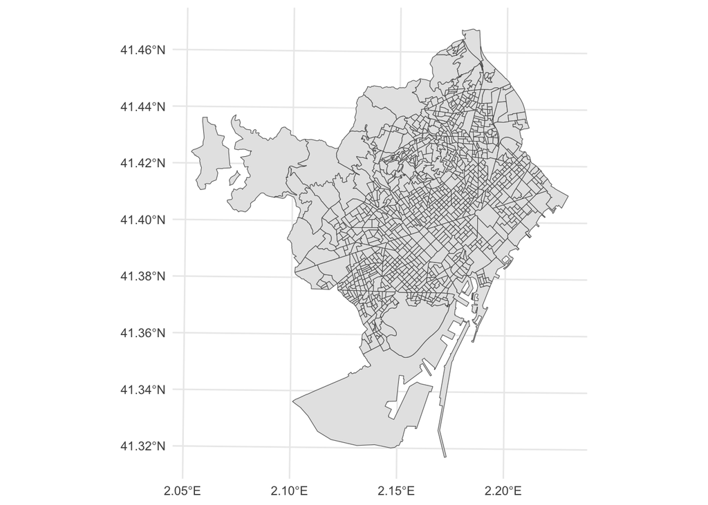

```r
# Census tract boundaries; keep the tracts of the selected city.
# (The first 5 characters of a tract code are the municipality code.)
tracts <- get_tract_geom(Year) %>%
  filter(substr(tract_code, 1, 5) == City)

# Attach the income shares to the boundaries
spatial_data <- inner_join(tracts, shares, by = "tract_code")

# Use coordinates in metres: EPSG:25831 (ETRS89 / UTM 31N) for Barcelona
spatial_data <- spatial_data %>%
  st_make_valid() %>%
  st_transform(25831)

ggplot() +
  geom_sf(data = spatial_data) +
  theme_minimal()
```

### Select a district

A Spanish census tract code has 10 characters: `PP MMM DD SSS`, i.e. province (2), municipality (3), **district (2)**, section (3). For example, `0801901001` is province `08`, municipality `019` (Barcelona), district `01`, section `001`. The district is therefore characters **6–7**.

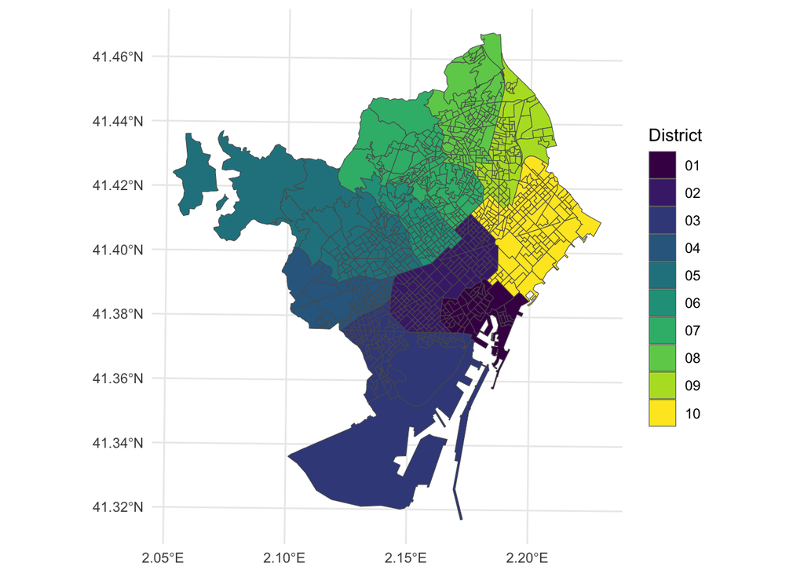

```r
spatial_data <- spatial_data %>%
  mutate(district = substr(tract_code, 6, 7))

# Sanity checks: every code has 10 characters, and the district exists
stopifnot(all(nchar(spatial_data$tract_code) == 10))
stopifnot(District %in% spatial_data$district)

ggplot() +
  geom_sf(data = spatial_data, aes(fill = district)) +
  scale_fill_viridis_d(name = "District") +
  theme_minimal()
```

```r
study_area <- spatial_data %>%
  filter(district == District)

cat("Tracts in the study area:", nrow(study_area), "\n")
```

```
Tracts in the study area: 54
```

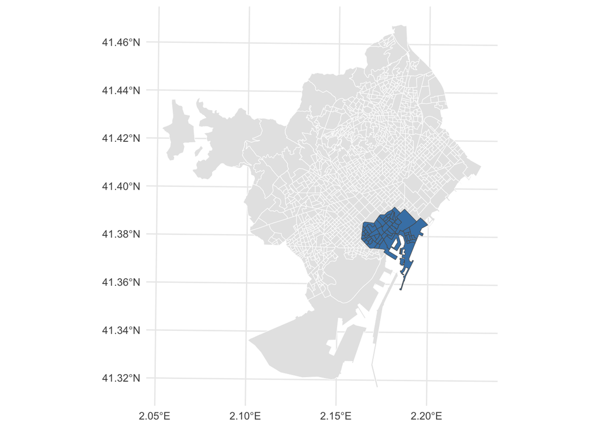

```r
ggplot() +
  geom_sf(data = spatial_data, fill = "grey90", colour = "white") +
  geom_sf(data = study_area, fill = "steelblue") +
  theme_minimal()
```

### From polygons to points

`spseg()` works with points, not polygons. We represent each tract by one point inside it, and keep the income data in **exactly the same row order** as those points.

```r
# One interior point per tract (guaranteed to fall inside the polygon,
# unlike the centroid of an oddly shaped tract)
points <- st_point_on_surface(st_geometry(study_area))
coords <- st_coordinates(points)   # matrix with X, Y in metres

# Income data in the same row order as coords
area_shares <- st_drop_geometry(study_area)
thresholds  <- names(area_shares)[grepl("^below_", names(area_shares))]

stopifnot(nrow(coords) == nrow(area_shares), !anyNA(area_shares$population))
```

## Calculate spatial Information Theory Indices (SITI)

For each income threshold, we split each tract’s population into two groups, *below* and *above* the threshold, and ask how unevenly the two groups are spread across space. `spseg()` does this in three steps:

1. it smooths the population of each group into a continuous surface with a Gaussian kernel of width `sigma` (our “scale”);
2. for every location it works out the income mix of its **local environment**;
3. it compares those local mixes with the mix of the whole study area.

The result, **H**, runs from 0 to 1:

- **H = 0:** every local environment has the same mix as the study area as a whole (perfect mixing).
- **H = 1:** every local environment contains only one group (complete separation).

We repeat this for every threshold and every scale.

```r
SITI_results <- data.frame()

for (scale in scales) {
  for (threshold in thresholds) {

    # Approximate number of people below and above this threshold, per tract
    database <- data.frame(
      Below = area_shares$population * area_shares[[threshold]],
      Above = area_shares$population * (1 - area_shares[[threshold]])
    )

    # Population rank of this threshold: the share of the study area's
    # population below it. (60% of the median is NOT the 60th percentile.)
    p <- sum(database$Below) / sum(area_shares$population)

    # H is undefined if everyone is on one side of the threshold
    if (p > 0 && p < 1) {
      message("Scale ", scale, " m, ", threshold, " ...")

      SITI_result <- seg_fixed$spseg(
        x = coords, data = database, method = "information",
        smoothing = "kernel", sigma = scale,
        useC = FALSE,           # see "Known issue 2"
        negative.rm = FALSE
      )

      SITI_results <- rbind(SITI_results, data.frame(
        Threshold = threshold, Group = p, Scale = scale, Value = SITI_result@h
      ))
    }
  }
}

SITI_results
```

```
          Threshold      Group Scale       Value
1        below_5000 0.09093697   250 0.006919429
2        below_7500 0.17626152   250 0.010895319
3       below_10000 0.27926929   250 0.015370207
4   below_40_median 0.16307372   250 0.010670621
5   below_50_median 0.23282612   250 0.013288195
6   below_60_median 0.31149437   250 0.016099429
7  below_140_median 0.78078921   250 0.033957486
8  below_160_median 0.83743259   250 0.035060499
9  below_200_median 0.90670289   250 0.037861817
10       below_5000 0.09093697   500 0.004455115
11       below_7500 0.17626152   500 0.008189958
12      below_10000 0.27926929   500 0.012014536
13  below_40_median 0.16307372   500 0.008037150
14  below_50_median 0.23282612   500 0.010283650
15  below_60_median 0.31149437   500 0.012422357
16 below_140_median 0.78078921   500 0.024176762
17 below_160_median 0.83743259   500 0.024413620
18 below_200_median 0.90670289   500 0.025307033
```

> **Note:** each `spseg()` call takes a few seconds, and longer at larger scales. If the loop is too slow for the time you have, run fewer thresholds or a single scale, or set `#| eval: false` on this chunk and discuss the logic instead.

### Reading the SITI results

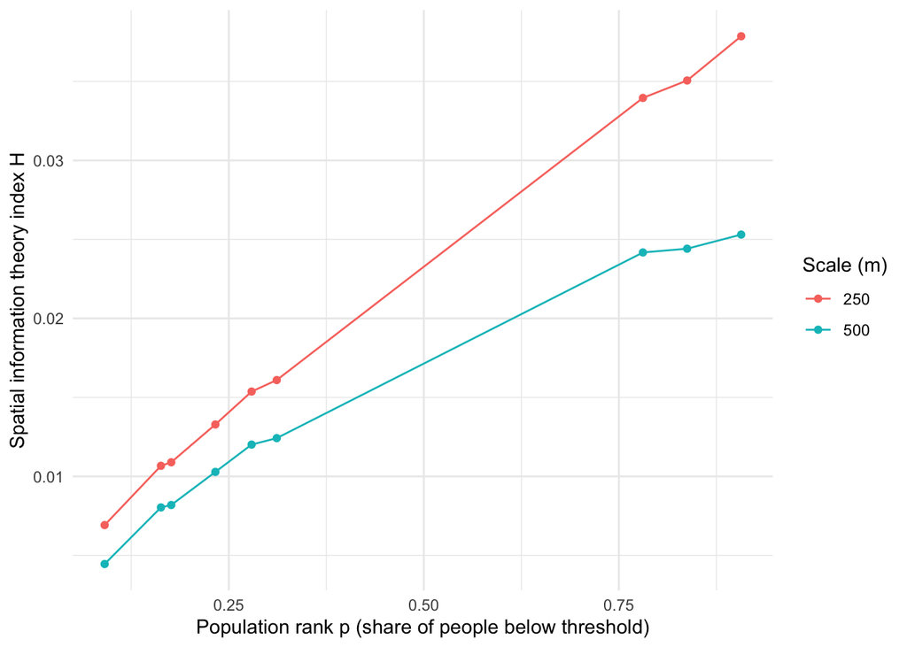

```r
ggplot(SITI_results, aes(Group, Value, colour = factor(Scale))) +
  geom_line() +
  geom_point() +
  labs(x = "Population rank p (share of people below threshold)",
       y = "Spatial information theory index H",
       colour = "Scale (m)") +
  theme_minimal()
```

Three things to look for:

- **Level:** values of 0.01–0.02 mean that the average local environment entropy is 1-2% lower than the study area entropy (for the particular below/above-income-threshold split). We can say that’s low.
- **Scale:** H usually falls as the scale grows. It does so because local environments encompass more people over a wider area, tending to mechanistically smooth differences in income composition.
- **Shape:** if H is higher at the right-hand end (high p, i.e. thresholds near the top of the income distribution), the well-off are more spatially concentrated than the poor.

## Calculate the Spatial Rank-Ordered Information Theory Index (SROITI)

SITI gives one H per threshold. SROITI summarises the whole curve in **one number per scale**, independent of which particular thresholds the data happen to provide. Following Reardon and Bischoff (2011), we:

1. fit a smooth curve H(p) through the points (a 4th-order polynomial);
2. average that curve over all ranks p from 0 to 1, giving more weight to ranks near the middle of the distribution, where splitting the population tells us the most (measured by the entropy E(p)).

$$H^R = 2\ln 2 \int_0^1 E(p)\,H(p)\,dp,
\qquad
E(p) = p\log_2\frac{1}{p} + (1-p)\log_2\frac{1}{1-p}$$

```r
# Entropy of a two-group split at population rank p
# (0 when everyone is in one group, 1 at an even 50/50 split)
entropy_function <- function(p) {
  if (p == 0 || p == 1) {
    return(0)
  } else {
    return(p * log2(1 / p) + (1 - p) * log2(1 / (1 - p)))
  }
}
```

```r
SROITI_results <- data.frame()

for (scale in scales) {

  # Segregation profile (H against p) for this spatial scale
  scale_data <- SITI_results %>% filter(Scale == scale)

  # A 4th-order polynomial needs comfortably more than 5 points
  stopifnot(length(unique(scale_data$Group)) >= 6)

  # Entropy at each observed population rank
  scale_data$Entropy <- sapply(scale_data$Group, entropy_function)

  # Fourth-order polynomial fit, weighted by squared entropy
  model <- lm(Value ~ poly(Group, 4), data = scale_data, weights = Entropy^2)

  # Integrate the fitted profile over p = 0..1, weighted by entropy
  integrand <- function(p) {
    H <- predict(model, newdata = data.frame(Group = p))
    2 * log(2) * sapply(p, entropy_function) * H
  }

  SROITI <- integrate(integrand, lower = 0, upper = 1, rel.tol = 1e-8)$value

  SROITI_results <- rbind(SROITI_results, data.frame(
    City = City, District = District, Year = Year,
    Scale = scale, SROITI = SROITI
  ))
}

SROITI_results
```

```
   City District Year Scale     SROITI
1 08019       01 2022   250 0.02307680
2 08019       01 2022   500 0.01684734
```

### Reading the SROITI results

SROITI is read like H: 0 = no segregation, 1 = complete separation, now averaged over the whole income distribution. The most informative comparison is **across scales**. The ratio between SROITI at 250 m and at 500 m can be said to roughly tell us the geographic scale of segregation (i.e. mosaic-like pattern of segregation vs. district-wide patterns of segregation).

SROITI values are only comparable with other areas or years computed **the same way** (same kind of units, kernel and scales). Comparing them with published values built on different units or methods is not meaningful.

## Discussion: from script to functions

> **Discuss:** `entropy_function()` only takes a single rank `p`, which is why we wrap it in `sapply()`. And everything above runs for one city and one district at a time.
> - How would you make `entropy_function()` work on a whole vector of `p` values at once?
> - What would it take to run this for *several* districts or cities in one go: a loop around everything above, or a function that wraps the whole pipeline and returns one row per area? Sketch the signature of that function together. What are its inputs, what does it return, and which parts of the script become their own smaller functions?